# Team 7: Spotify Songs Analysis

Understanding these trends in average track durations within different genres offers insights into the industry’s composition and production tendencies. It also sheds light on the audience’s preferences for song length and can guide musicians and producers in optimizing their creative processes.

Genres like Techno and Psytrance have the longest average track durations, possibly reflecting their emphasis on extended musical compositions and immersive sonic experiences. Hiphop, Trap Metal, and Emo, on the other hand, exhibit comparatively shorter average track durations, suggesting a focus on concise and impactful musical expressions within these genres. Most genres maintain tracks that average between 120,000 and 240,000 milliseconds (or 2 to 4 minutes) in duration, highlighting a shared inclination toward maintaining an optimal balance between musical creativity and listener engagement.

**3. Is there a significant difference in the loudness of tracks between the genres Dark Trap and Underground Rap? (T-Test)**

A t-test is an inferential statistic used to determine if there is a significant difference between the means of two groups and how they are related. T-tests are used when the data sets follow a normal distribution and have unknown variances, like the data set recorded from flipping a coin 100 times.The t-test is a test used for hypothesis testing in statistics and uses the t-statistic, the t-distribution values, and the degrees of freedom to determine statistical significance.**[7]**

Now let us use a T-Test for trying to answer the SMART question-

```r
dark_trap <- subset(dataset_na, genre == "Dark Trap")$loudness
underground_rap <- subset(dataset_na, genre == "Underground Rap")$loudness

# Performing the T-test
test_result <- t.test(dark_trap, underground_rap)

# Extract the t-statistic and p-value
t_stat <- test_result$statistic
p_value <- test_result$p.value

results <- data.frame(T_Statistic = t_stat, P_Value = p_value)
results
```

```
##   T_Statistic      P_Value
## t   -10.80373 4.816667e-27
```

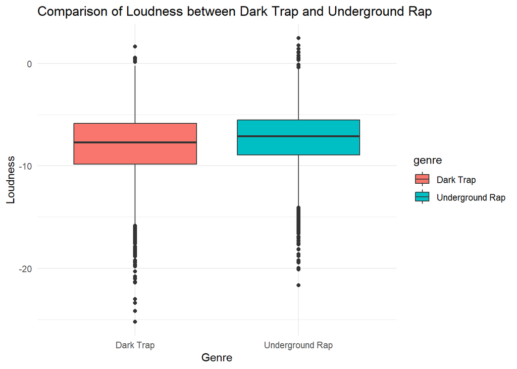

```r
library(ggplot2)

# Subset the data for the two genres
relevant_data <- subset(dataset_na, genre %in% c("Dark Trap", "Underground Rap"))

# Create a box plot
ggplot(relevant_data, aes(x = genre, y = loudness, fill = genre)) +
  geom_boxplot() +
  labs(title = "Comparison of Loudness between Dark Trap and Underground Rap",
       x = "Genre",
       y = "Loudness") +
  theme_minimal()
```

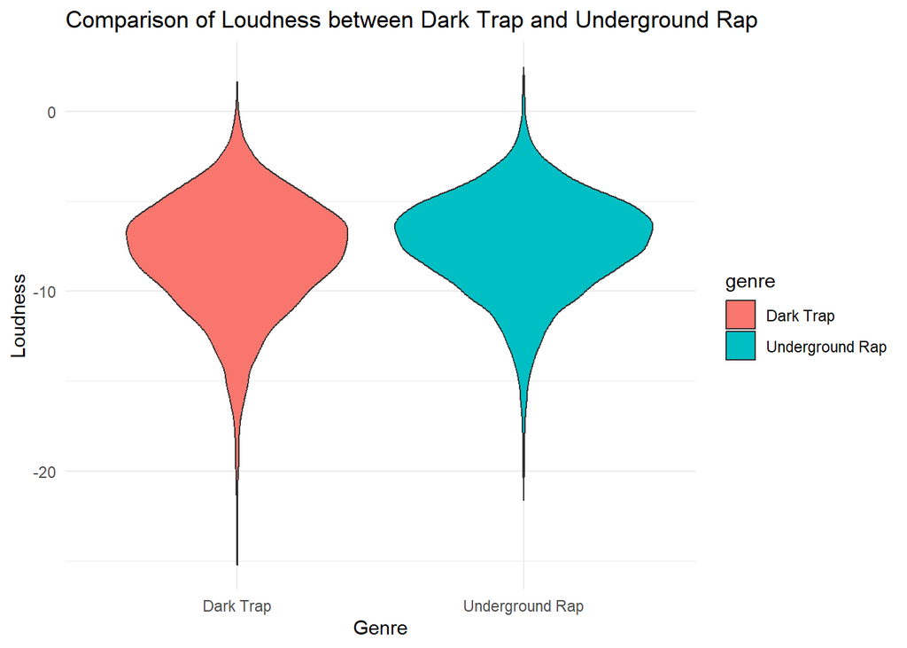

```r
ggplot(relevant_data, aes(x = genre, y = loudness, fill = genre)) +
  geom_violin() +
  labs(title = "Comparison of Loudness between Dark Trap and Underground Rap",
       x = "Genre",
       y = "Loudness") +
  theme_minimal()
```

```r
library(dplyr)

# Performing the ANOVA
model <- aov(loudness ~ genre, data = dataset_na)

# Summarize the ANOVA results
summary(model)
```

```
##                Df Sum Sq Mean Sq F value Pr(>F)
## genre          14 117313    8380    1425 <2e-16 ***
## Residuals   42290 248635       6
## ---
## Signif. codes:  0 '***' 0.001 '**' 0.01 '*' 0.05 '.' 0.1 ' ' 1
```

*T-Test Observation*

Null Hypothesis: The mean “loudness” of songs in the “Underground Rap” genre is equal to the mean “loudness” of songs in the “Dark Trap” genre.

In practical terms, this statistical outcome suggests that there is a substantial distinction in the loudness characteristics between “Underground Rap” and “Dark Trap” genres. This distinction in loudness could be an essential element in defining the auditory experience and emotional impact of the music within these distinct genres, thereby highlighting the significance of loudness as a key factor in the sonic identity and aesthetic appeal of musical compositions.

In this case, the T-statistic was utilized to compare the means of the loudness values between the two genres, providing valuable insights into the significant differences and distinct auditory profiles associated with “Underground Rap” and “Dark Trap” genres.

**4. Is there an association between key (musical key of the track) and genre? (Chi-square test)**

A chi-square (χ2) statistic is a test that measures how a model compares to actual observed data. The data used in calculating a chi-square statistic must be random, raw, mutually exclusive, drawn from independent variables, and drawn from a large enough sample. For example, the results of tossing a fair coin meet these criteria.

Chi-square tests are often used to test hypotheses. The chi-square statistic compares the size of any discrepancies between the expected results and the actual results, given the size of the sample and the number of variables in the relationship.**[8]**

Now let us use a CHi-sqaure test to analyse the above SMART question-

```r
contingency_table <- table(dataset_na$key, dataset_na$genre)

# Performing the chi-square test
test_result <- chisq.test(contingency_table)

test_result$statistic
```

```
## X-squared
##  3091.281
```

```r
test_result$p.value
```

```
## [1] 0
```

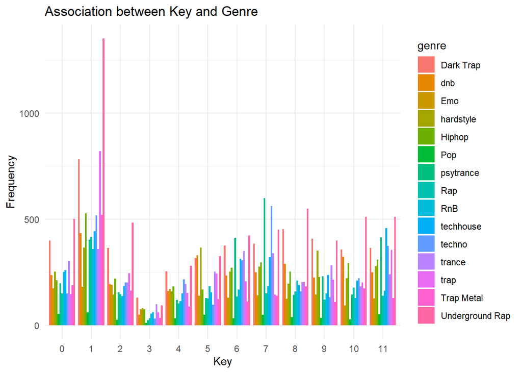

```r
library(ggplot2)

# Creating a clustered bar plot
ggplot(dataset_na, aes(x = factor(key), fill = genre)) +
  geom_bar(position = "dodge") +
  labs(x = "Key", y = "Frequency", title = "Association between Key and Genre") +
  theme_minimal()
```

*Chi-Square Test Observation*

Null Hypothesis: The “key” and “genre” are independent of each other. i.e., There is no association between the musical key of the track and its genre.

In this scenario, the Chi-square statistic value serves as an indicator of the strength of the association between the key and the genre of the tracks. The calculated Chi-square statistic value is 3091.2811881, which is notably high and suggests a substantial association between the musical key and the genre of the tracks.

The P-value, a measure of the probability of obtaining the observed data given that the null hypothesis is true, is reported as 0. This exceptionally low P-value strongly suggests that the observed association between the key and genre is highly unlikely to occur if there were no actual association. Consequently, we have sufficient evidence to reject the null hypothesis in favor of the alternate hypothesis, indicating that there is indeed a significant association between the musical key and the genre of the tracks in this dataset.

This statistical finding implies that the choice of musical key might be a defining characteristic that contributes to the differentiation and identification of various genres. The relationship between the key and the genre could potentially serve as an essential factor in the classification and analysis of music, providing insights into the distinctive musical patterns and elements that define specific genres based on their tonal characteristics.

In this analysis, the Chi-square statistic was employed to test for associations between categorical variables, highlighting the significant relationship between the musical key and the genre of the tracks in the dataset.

**5. Is there a significant difference in energy levels across the genres Dark Trap, Underground Rap, and Emo? (ANOVA test)**

Analysis of variance (ANOVA) is an analysis tool used in statistics that splits an observed aggregate variability found inside a data set into two parts: systematic factors and random factors. The systematic factors have a statistical influence on the given data set, while the random factors do not. Analysts use the ANOVA test to determine the influence that independent variables have on the dependent variable in a regression study.**[9]**

Now let us use a ANOVA test to analyse the above SMART question-

```r
# Filter the data for the three genres of interest
dark_trap <- dataset_na[dataset_na$genre == "Dark Trap",]$loudness
underground_rap <- dataset_na[dataset_na$genre == "Underground Rap",]$loudness
emo <- dataset_na[dataset_na$genre == "Emo",]$energy

# Combine data from the three genres into one vector
combined_data <- c(dark_trap, underground_rap, emo)

# Create a factor to identify genre membership for each data point
group <- factor(c(rep("Dark Trap", length(dark_trap)),
                 rep("Underground Rap", length(underground_rap)),
                 rep("Emo", length(emo))))

# Perform the ANOVA test
anova_result <- aov(combined_data ~ group)

# Extract the F-statistic and p-value
summary_result <- summary(anova_result)
f_stat_anova <- summary_result[[1]]$F[1]
p_value_anova <- summary_result[[1]]$"Pr(>F)"[1]

results_anova <- data.frame(F_Statistic = f_stat_anova, P_Value = p_value_anova)
results_anova
```

```
##   F_Statistic P_Value
## 1    6932.397       0
```

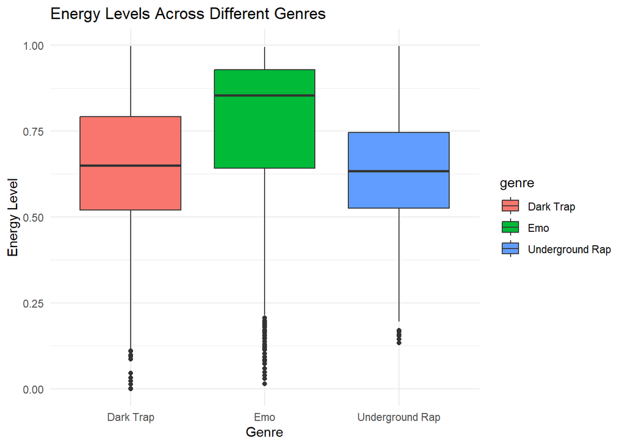

```r
library(ggplot2)

# Filter the data for the specified genres
filtered_data <- dataset_na[dataset_na$genre %in% c("Dark Trap", "Underground Rap", "Emo"), ]

# Create a boxplot
ggplot(filtered_data, aes(x = genre, y = energy, fill = genre)) +
  geom_boxplot() +
  labs(title = "Energy Levels Across Different Genres",
       x = "Genre",
       y = "Energy Level") +
  theme_minimal()
```

ANOVA Test Observation

Null Hypothesis: There is no significant difference in energy levels across the genres Dark Trap, Underground Rap, and Emo.

In this context, the F-statistic value and the associated P-value help in evaluating the significance of the observed differences in energy levels among the genres Dark Trap, Underground Rap, and Emo.

The ANOVA test utilizes the F-statistic to compare the means of three or more groups, enabling the assessment of significant differences in energy levels across various music genres.

# **Future Objectives and Conclusion**

Popularity is a subjective metric that can be influenced by various factors and contexts. A basic popularity formula could involve a combination of energy, danceability, and tempo to derive a popularity score. The formula considers the positive impact of energy and danceability, while accounting for the negative impact of acousticness, instrumentalness, and liveness. The inclusion of tempo in the formula highlights its role in determining overall popularity.

Popularity Formula:

*Popularity=(danceability×energy+tempo)−(acousticness+instrumentalness+liveness)*

As part of future research and analysis, refining the popularity formula and considering other influential factors is a valuable objective. Adjustments and the incorporation of additional attributes, such as lyrical content, sentiment analysis, and listener engagement metrics, can enhance the accuracy and comprehensiveness of the popularity metric. Exploring the impact of cultural trends, regional preferences, and emerging musical styles on the overall perception of popularity can further enrich the formula, providing a more nuanced understanding of the diverse factors that contribute to a song’s appeal and success in the contemporary music landscape. The development of an inclusive and comprehensive popularity formula can serve as a valuable tool for music professionals, researchers, and enthusiasts, facilitating a more nuanced and informed evaluation of musical trends and preferences.

The exploratory data analysis (EDA) conducted on the Spotify music dataset provided valuable insights into the diverse musical landscape, showcasing the distinct distributions of features such as danceability, energy, and loudness among various genres. The observed statistical variances and significant differences in certain audio features between genres not only deepen our understanding of their unique musical compositions but also offer crucial cues for future research endeavors. These findings serve as a springboard for the exploration of predictive models for song popularity, the enhancement of music recommendation systems, and a more comprehensive understanding of the evolving trends in the dynamic and ever-evolving music industry. By leveraging the multifaceted insights gleaned from this analysis, researchers and industry professionals can continue to unravel the complex interplay of musical attributes and audience preferences, fostering a more nuanced and data-driven approach to music production, distribution, and consumption in the digital age.

# **References**

[1] ANDRII SAMOSHYN, Dataset of songs in Spotify,Kaggle Retrieved on Oct 18,2023; https://www.kaggle.com/datasets/mrmorj/dataset-of-songs-in-spotify

[2] Prasad Patil, Published in Towards Data Science (Mar 23,2018), Retrieved on Oct 31,2023; https://towardsdatascience.com/exploratory-data-analysis-8fc1cb20fd15

[3] What is exploratory data analysis?, IBM, Retrieved on Oct 31,2023; https://www.ibm.com/topics/exploratory-data-analysis

[4] Codecademy Team, Exploratory Data Analysis: Data Visualization, Retrieved on Oct 31,2023; https://www.codecademy.com/article/eda-data-visualization

[5] Henrik von Wehrden, Correlation Plots, Retrieved on Oct 31,2023; https://sustainabilitymethods.org/index.php/Correlation_Plots#:~:text=7%20References-,What%20are%20correlation%20plots%3F,the%20causality%20between%20the%20variables!

[6] Taiyun Wei, Viliam Simko, An Introduction to corrplot Package, 2021-11-18, Retrieved on Oct 31,2023; https://cran.r-project.org/web/packages/corrplot/vignettes/corrplot-intro.html

[7] Adam Hayes, T-Test: What It Is With Multiple Formulas and When To Use Them, April 5th 2023, Retrieved on Oct 31,2023; https://www.investopedia.com/terms/t/t-test.asp

[8] Adam Hayes, Chi-Square (χ2) Statistic: What It Is, Examples, How and When to Use the Test, May 22nd 2023, Retrieved on Oct 31,2023; https://www.investopedia.com/terms/c/chi-square-statistic.asp

[9] Will Kenton, Analysis of Variance (ANOVA) Explanation, Formula, and Applications, June 12th 2023, Retrieved on Oct 31,2023; https://www.investopedia.com/terms/a/anova.asp